# Welcome to MATH3024: (Modelling) Complex Systems

#### Why study Complex Systems at UWA?

[figure not shown]

Who, What, When, Where, Why, How...?

→ see LMS

Slides will be minimal, key material from lectures is all in the Reader

# Modelling

All of science relies on models.

## Our 'model' models

We will introduce most of the ideas today via two different observations and the models that were proposed to investigate them:

1. Planetary orbits are elliptical
2. Parts of society are segregated

### Segregation

**Schelling's observation:**

[figure not shown]

**The model:** What's the general principle? What's the differential equation we can sit down and solve with a pen?

#### We'll need a different approach...

This is a story of how harmless choices can make a harmful world.

— [Parable of the Polygons](https://ncase.me/polygons/) by Vi Hart and Nicky Case.

[figure not shown]

# Complex Systems

I think the next (21st) century will be the century of complexity.

— Stephen Hawking

Note that I will typically capitalise the discipline and use lower case for a system that is complex.

## Complex Systems (the field)

aka called Complexity Science. The interdisciplinary study of how interactions give rise to emergent behaviour in systems across nature, society, and technology.

This is essentially a diverse and adaptable toolkit for dealing with complex systems.

[figure not shown]

**Complexity** comes from the Latin word *“plexus”*, which indicates non-separability of components

[figure not shown]

## Complex systems (the systems)

The actual systems themselves — made up of many interacting parts that influence one another in non-trivial ways.

These interactions can produce **emergent behaviour** — patterns, structures, or dynamics not present in any individual component.

[video not shown]

#### Complex Systems Thinkers see things differently

[figure not shown]

Fig: *An Introduction to Complex Systems Science and Its Applications by A F. Siegenfeld*, [2020])

# Let's model!

All models are wrong, but some are useful.

— George Box, 1976

### Assumptions

Occam's razor: the principle of parsimony.

Entities must not be multiplied beyond necessity.  
All thing being equal, the simplest explanation is the best one.

— William of Ockham (English philosopher)

### What goes in to a model?

There are laws of physics and there are rules of life — and rules are meant to be broken.

— David Krakauer, *Foundational Papers in Complexity Science*, Vol. 1, p. 6

- **Independent variable:** usually time as we tend to think about systems evolving in time (even if there are multiple independent variables as with wave propagation and heat diffusion). This is our way of thinking about causality — a system's state depends on its previous states in time. Time can be discrete, or aligned with events
- **Structure:** rules of the system. Format of the rules can be sentences, algorithms, equations ((O, S, P)DEs, difference equations)
- **Data:** serves as an input to the rules. Could be as simple as an initial condition but could be continuously interacting. Real or contrived
- **Inputs:** parameters, degrees of freedom
- **Dynamics:** the rules of the game

### What comes out of a model?

- **Outputs:** qualitative and quantitative analysis in the form of various visualisations and abstractions of the resulting behaviour

### Model details: The original Parable of the Polygons

# Let's code!

We **have to** code!

## The Parable I

Let's keep it similar to the Parable of Polygons but be more explicit about our assumptions:

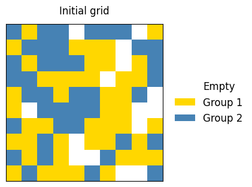

### Dynamics

- **Neighbourhood:** Moore, not including self. Entirely summarised by similarity ratio $\frac{n_s}{n}$, where $n_s$ are the number of similar neighbours in the neighbourhood and $n = \{1,\ldots,8\}$ is the number of total neighbours
- **Dynamics:** Based on local neighbourhood similarity ratio and a threshold $\theta_r=50\%$. Agent is unhappy and will want to move if $\frac{n_s}{n}<\theta_r$. Randomly selected unhappy agent will move to random empty location

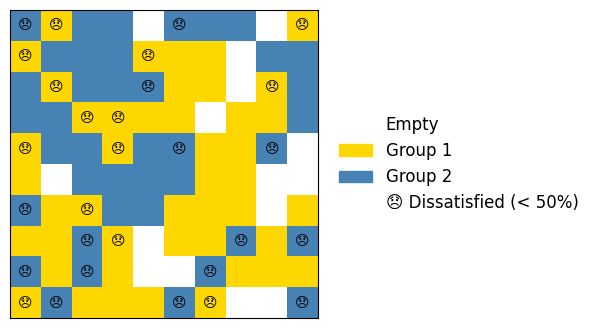

[figure not shown]

But this is only a gif... We want direct and interactive control of the independent variable (time).

### Qualitative analysis

We don't need the bells and whistles, and of course we start small

Looks like segregation... is it?

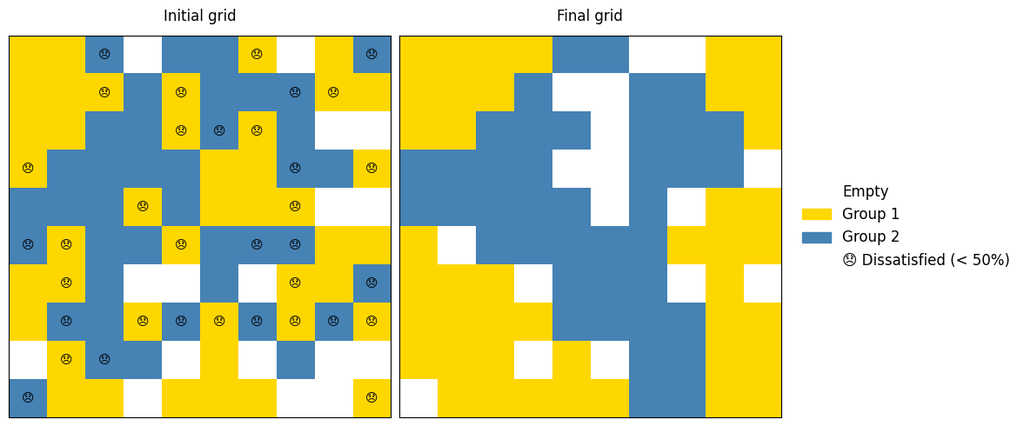

### Quantitative analysis

We want to measure the amount of segregation so we better actually define it.

*Definition:* Segregation is the degree to which two or more groups live separately from one another.

But groups can live apart and be 'segregated' in a variety of ways...

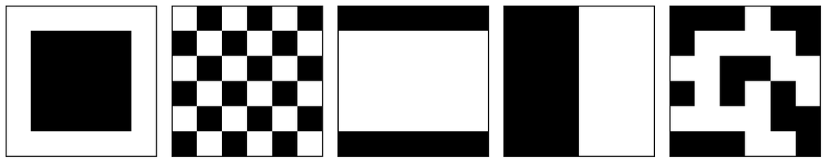

##### *One* option for quantifying segregation

The mean similarity ratio:

$$ \mathcal{MSR}=\frac{1}{N}\sum_i^N \frac{n_s}{n}, $$

where $n_s$, $n_e$, $n$ denote the number of similar, empty and total neighbours in a Moore neighbourhood of the individual $i$. Hence, $n=9-1-n_e$

This is what we will *choose* (and what Schelling used). But there are many other choices.

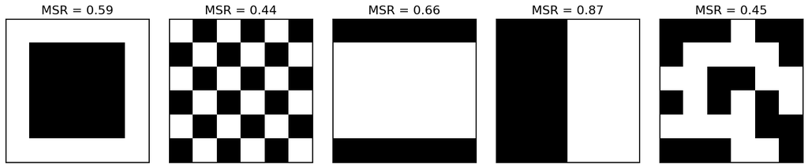

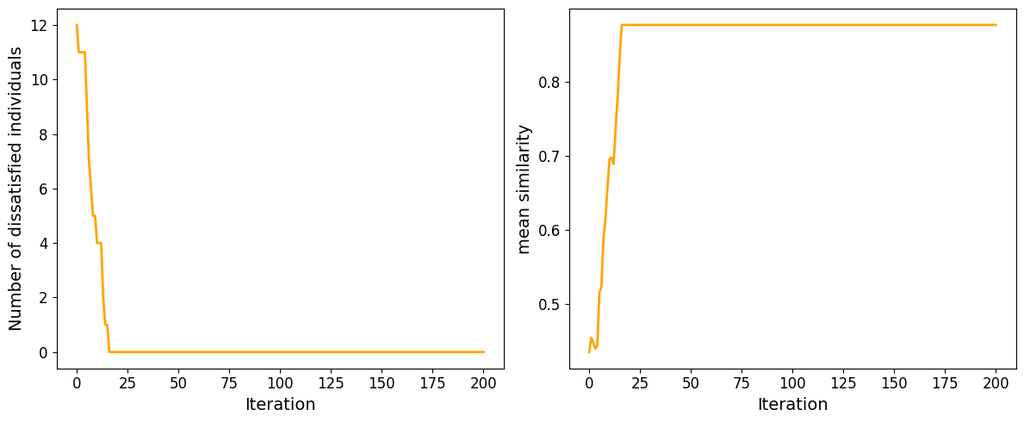

Great, everything seems to be working...

What about other initialisations?

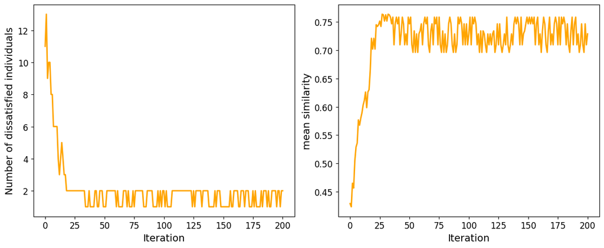

Maybe we haven't run the simulation long enough to reach a steady state?

Back down the ladder to see what's happening in the simulation at this time.

## The parable II

We have replicated the Parable of the Polygons

Now what...?

It's not even close to being enough.

### Varying important parameters

Why is the neighbourhood threshold 50%?

It's a good start but this is clearly a a crucial parameter so we must understand how the system behaviour changes when it does

Let's look at how the MSR changes as a function of the threshold percentage, i.e. abstract over the parameter (up the ladder again)

This is called a **parameter sweep**.

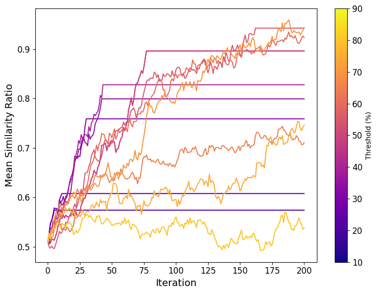

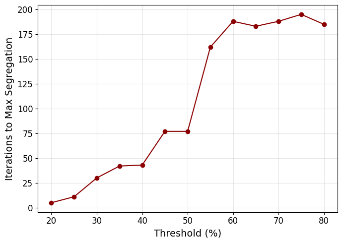

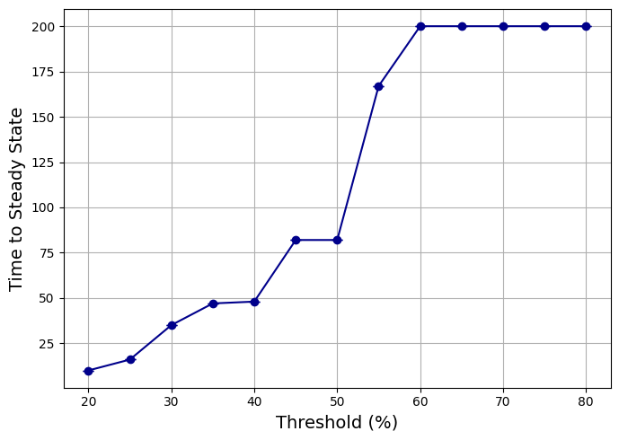

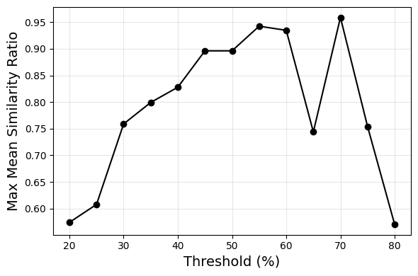

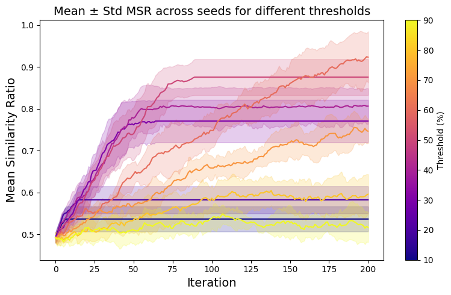

This is messy and difficult to interpret. Let's collapse each time series to a summary statistic.

Back up the ladder as we abstract over time...

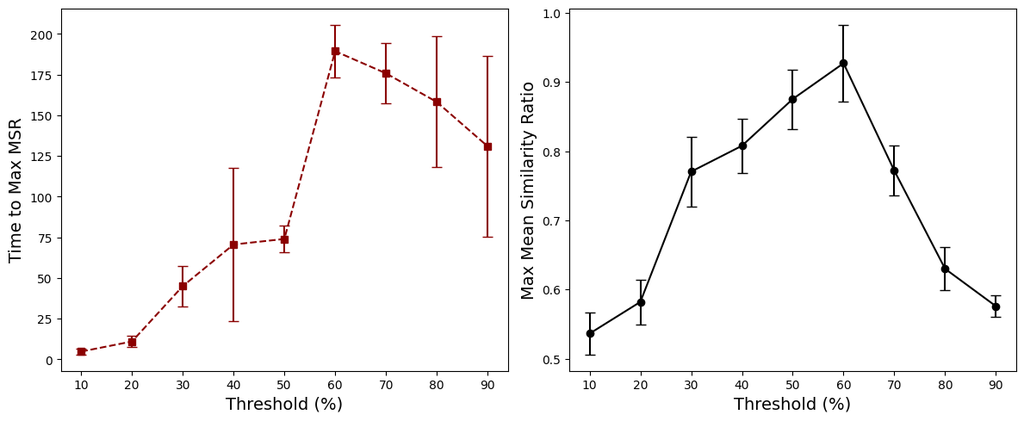

Time for us to have a break, and our machines to go to work.

**This is why you must get started on your Projects early!**

# Final thoughts

[video not shown]

#### The biggest challenges of the 21st century are 'complex'

These challenges are:

- tied together by a common theme: emergent complexity in highly-interconnected systems
- at the boundary of theory and the unknown
- not so unknown that they're hopeless, but there's not enough theory to predict the results of our decisions.

Find one that excites you and build your project around it.